# Node analysis of social connectedness and health inequalities

Following up on our discussion last week, we now look at five things specifically:

1. Reduce multicollinearity by using just one SCI variable and no interactions
2. Adding countries not as random, but fixed effects
3. Consider moving to multi-level modelling
4. Avoid overfitting by using the HDI as the only control (besides SCI and countries)
5. Focus on outcomes related to sexual and reproductive health. This means dropping child vaccination outcomes and adding outcomes on knowledge and behaviour related to HIV and FGM

### Relevant libraries

```r
library(tidyverse)    # Data wrangling
library(sf)           # Spatial analysis
library(caret)        # For machine learning and preprocessing
library(spdep)        # For spatial analysis
library(spatialreg)   # For spatial regressions
library(olsrr)        # For OLS residual diagnostics
library(lme4)         # For random effects models
library(lmerTest)     # For approximated p-values in mixed models
library(ggplot2)      # Visualizations
library(broom)        # For data.frame-like summary outputs
library(survey)        # For weighted modelling

library(sjPlot)       # for tab_model function

select <- dplyr::select
```

### Relevant data

```r
# Map data
afr_dat <- st_read(dsn = "/Users/tillkoebe/Documents/GitHub/health_inequalities/combined_dataset/GADM_1_geometries.gpkg") %>%
  st_make_valid() %>%
  st_transform(4326)
# Social Connectedness Index
sci <- read.csv("/Users/tillkoebe/Documents/GitHub/health_inequalities/external_dataset/sci_indices.csv") %>%
  distinct(user_loc, .keep_all = T)

# Worldpop covariates
wp <- read.csv("/Users/tillkoebe/Documents/GitHub/health_inequalities/external_dataset/wp.csv") %>%
  distinct(GID_1, .keep_all = T)

# Human Development Index
hdi <- read.csv("/Users/tillkoebe/Documents/GitHub/health_inequalities/external_dataset/hdi.csv") %>%
  distinct(GID_1, .keep_all = T)

# Facebook covariates
fb <- read.csv("/Users/tillkoebe/Documents/GitHub/health_inequalities/external_dataset/fb.csv") %>%
  distinct(GID_1, .keep_all = T)

# DHS data
dhs <- read.csv('/Users/tillkoebe/Documents/GitHub/health_inequalities/external_dataset/dhs_health_individual.csv')

# Afrobarometer
afr <- read.csv('/Users/tillkoebe/Documents/GitHub/health_inequalities/external_dataset/afrobarometer.csv') %>%
  distinct(GID_1, .keep_all = T)
```

### Defining targets and controls

Let’s define our targets and controls:

```r
### Define targets
dhs_targets <- dhs %>%
  select(rh_anc_pv:fg_cont) %>%
  select(starts_with(c('fp', 'hk'))) %>% #'rh',
  select(-fp_message_noneof4, -hk_sexprtnr_num, -hk_cond_2plus, -hk_cond_notprtnr, hk_atd_shop_notbuy) %>% #excluded as they either reduce sample size or they are out of the 0-1 range
  # select(fp_know_any, fp_know_mod, hk_ever_heard, hk_knw_risk_sex, hk_knw_risk_cond) %>%
  names()

### Define controls
dhs_controls <- c(
  'v104', # gender
  'v105', # age
  'v025', # urban/rural
  'v106', # highest educational level
  'v243a', # mobile phone ownership
  'v270' # wealth index by quintiles
)

sci_controls <- c('Mean_dist_to_SCI_km', # Average distance of friendships
                  'Median_dist_to_SCI_km', # Average distance of friendships
                  'Std_dist_to_SCI_km', # Clustering measure of friendships across distances
                  'Total_dist_to_SCI_km', # Total distance of friendships
                  'Ratio_selfloop_to_country', # Share of local friendships within the same country
                  'Ratio_selfloop_to_africa', # Share of local friendships that stay within Africa
                  'Ratio_selfloop_to_all_sci', # Share of local friendships of all friendships
                  'Average_distance_of_friendships_km',
                  'Mean_SCI_without_Self', # Average probability of friendships with other regions
                  'Median_SCI_without_Self', # Average probability of friendships with other regions
                  'Std_SCI_without_Self', # Clustering measure for the probability of friendships with other regions
                  'Mean_SCI_with_Self', # Average probability of friendships across all regions
                  'Median_SCI_with_Self', # Average probability of friendships across all regions
                  'Std_SCI_with_Self', # Average probability of friendships across all regions
                  'Mean_friendship', # Average friendships per FB users
                  'Median_friendship', # Average friendships per FB users
                  'Std_friendship', # Clustering measure for friendships per FB user
                  'Total_friendship', # Sum of friendships per FB user
                  'Ratio_SCI_low_hi_africa', # Share of friendships to regions with a low health index
                  'Ratio_SCI_middle_hi_africa', # Share of friendships to regions with a medium health index
                  'Ratio_SCI_high_hi_africa' # Share of friendships to regions with a high health index
)

hdi_controls <- c('HDI')

wp_controls <- c(
  'Mean_of_Night_Light',
  'Std_of_Night_Light',
  'Mean_distance_to_major_rd_intersection',
  'Std_distance_to_major_rd_intersection',
  'Mean_distance_to_major_rd',
  'Std_distance_to_major_rd',
  "Mean_distance_to_inland_water",
  "Std_distance_to_inland_water",
  "Mean_built_settlement_growth",
  "Std_built_settlement_growth")

fb_controls <- c('fb_rwi_mean',
                 'fb_rwi_mean_pop_wght',
                 'FB_pntr_15to49_female',
                 'FB_pntr_15to49_all')

afr_controls <- c('member_community',
                  'trpar',
                  'trtax',
                  'trgov',
                  'trlaw',
                  'trgen',
                  'trrel',
                  'trnei',
                  'tracq',
                  'railway_contact',
                  'explorer_contact',
                  'district_ethnic_frac',
                  'loc_ln_export_area')
```

We then merge datasets and create the country dummy:

```r
dat <- dhs %>%
  select(pid,
         v021,
         strata,
         wt,
         GID_1 = gid_1,
         all_of(dhs_targets),
         all_of(dhs_controls)) %>%
  left_join(sci %>%
              select(GID_1 = user_loc,
                     all_of(sci_controls)),
            by = 'GID_1') %>%
  left_join(hdi %>%
              select(GID_1,
                     all_of(hdi_controls)),
            by = 'GID_1') %>%
  left_join(wp %>%
              drop_na(GID_1) %>%
              select(GID_1,
                     all_of(wp_controls)),
            by = 'GID_1') %>%
  left_join(fb %>%
              select(GID_1,
                     all_of(fb_controls)),
            by = 'GID_1') %>%
  left_join(afr %>%
              select(GID_1,
                     all_of(afr_controls)),
            by = 'GID_1') %>%
  mutate(iso3 = substr(GID_1, 1, 3))
```

Here an overview of the variables we now have in our dataset:

```r
dim(dat)
```

```
## [1] 706861     83
```

```r
names(dat)
```

```
##  [1] "pid"
##  [2] "v021"
##  [3] "strata"
##  [4] "wt"
##  [5] "GID_1"
##  [6] "fp_know_any"
##  [7] "fp_know_mod"
##  [8] "fp_know_trad"
##  [9] "fp_message_noneof3"
## [10] "hk_sex_2plus"
## [11] "hk_sex_notprtnr"
## [12] "hk_ever_heard"
## [13] "hk_knw_risk_cond"
## [14] "hk_knw_risk_sex"
## [15] "hk_knw_risk_condsex"
```

[output cut: 68 more lines]

A description of the variables can be found [here](https://drive.google.com/file/d/1vCgciS4_zMz6hs5SoRl8_5yxP5drHt1C/view?usp=sharing).

### Summary statistics

```r
dat %>%
  select(all_of(dhs_targets)) %>%
  summary()
```

```
##   fp_know_any     fp_know_mod      fp_know_trad    fp_message_noneof3
##  Min.   :0.000   Min.   :0.0000   Min.   :0.0000   Min.   :0.000
##  1st Qu.:1.000   1st Qu.:1.0000   1st Qu.:0.0000   1st Qu.:0.000
##  Median :1.000   Median :1.0000   Median :1.0000   Median :1.000
##  Mean   :0.941   Mean   :0.9364   Mean   :0.6644   Mean   :0.577
##  3rd Qu.:1.000   3rd Qu.:1.0000   3rd Qu.:1.0000   3rd Qu.:1.000
##  Max.   :1.000   Max.   :1.0000   Max.   :1.0000   Max.   :1.000
##  NA's   :2523    NA's   :2523     NA's   :2756     NA's   :24625
##   hk_sex_2plus     hk_sex_notprtnr  hk_ever_heard    hk_knw_risk_cond
##  Min.   :0.00000   Min.   :0.0000   Min.   :0.0000   Min.   :0.0000
##  1st Qu.:0.00000   1st Qu.:0.0000   1st Qu.:1.0000   1st Qu.:0.0000
##  Median :0.00000   Median :0.0000   Median :1.0000   Median :1.0000
##  Mean   :0.05926   Mean   :0.1664   Mean   :0.8774   Mean   :0.6664
##  3rd Qu.:0.00000   3rd Qu.:0.0000   3rd Qu.:1.0000   3rd Qu.:1.0000
##  Max.   :1.00000   Max.   :1.0000   Max.   :1.0000   Max.   :1.0000
##
##  hk_knw_risk_sex  hk_knw_risk_condsex hk_knw_hiv_hlth  hk_knw_hiv_mosq
##  Min.   :0.0000   Min.   :0.0000      Min.   :0.0000   Min.   :0.0000
##  1st Qu.:0.0000   1st Qu.:0.0000      1st Qu.:0.0000   1st Qu.:0.0000
##  Median :1.0000   Median :1.0000      Median :1.0000   Median :1.0000
##  Mean   :0.7466   Mean   :0.6223      Mean   :0.6794   Mean   :0.5659
##  3rd Qu.:1.0000   3rd Qu.:1.0000      3rd Qu.:1.0000   3rd Qu.:1.0000
##  Max.   :1.0000   Max.   :1.0000      Max.   :1.0000   Max.   :1.0000
##
##  hk_knw_hiv_supernat hk_knw_hiv_food  hk_knw_hiv_hlth_2miscp hk_knw_comphsv
##  Min.   :0.0000      Min.   :0.0000   Min.   :0.000          Min.   :0.0000
##  1st Qu.:0.0000      1st Qu.:0.0000   1st Qu.:0.000          1st Qu.:0.0000
##  Median :1.0000      Median :1.0000   Median :0.000          Median :0.0000
##  Mean   :0.6225      Mean   :0.6578   Mean   :0.406          Mean   :0.3297
##  3rd Qu.:1.0000      3rd Qu.:1.0000   3rd Qu.:1.000          3rd Qu.:1.0000
##  Max.   :1.0000      Max.   :1.0000   Max.   :1.000          Max.   :1.0000
##
##  hk_knw_mtct_preg hk_knw_mtct_deliv hk_knw_mtct_brfeed hk_knw_mtct_all3
##  Min.   :0.0000   Min.   :0.0000    Min.   :0.0000     Min.   :0.0000
##  1st Qu.:0.0000   1st Qu.:0.0000    1st Qu.:0.0000     1st Qu.:0.0000
##  Median :1.0000   Median :1.0000    Median :1.0000     Median :0.0000
##  Mean   :0.6034   Mean   :0.6549    Mean   :0.6689     Mean   :0.4964
##  3rd Qu.:1.0000   3rd Qu.:1.0000    3rd Qu.:1.0000     3rd Qu.:1.0000
##  Max.   :1.0000   Max.   :1.0000    Max.   :1.0000     Max.   :1.0000
##
##  hk_knw_mtct_meds hk_atd_shop_notbuy
##  Min.   :0.0000   Min.   :0.00
##  1st Qu.:0.0000   1st Qu.:0.00
##  Median :1.0000   Median :0.00
##  Mean   :0.5564   Mean   :0.38
##  3rd Qu.:1.0000   3rd Qu.:1.00
##  Max.   :1.0000   Max.   :1.00
##                   NA's   :38082
```

#### Preprocessing

Before we start looking at spatial autocorrelation and other modelling outcomes, we need to prepare our final dataset.

We center and scale SCI and WP features

```r
# Center and scale SCI variables
dat <- dat %>%
  mutate(across(all_of(sci_controls), ~ scale(.x, scale = T)),
         across(all_of(wp_controls), ~ scale(.x, scale = T))
         )
```

#### Modelling approaches

Both scenarios are not robust across samples or minor changes in specifications (e.g. adding/removing interaction effects)

Same observations hold true when using the general trust variable instead of the SCI.

Here a summary of the results for the first scenario:

```r
interactions <- ('v104:v243a +
                v104:Mean_friendship +
                v243a:Mean_friendship')

controls <- c('Mean_friendship +
              v104 +
              v105 +
              v025 +
              v106 +
              v243a +
              v270 +
              Mean_of_Night_Light +
              Mean_distance_to_major_rd +
              Mean_built_settlement_growth +
              FB_pntr_15to49_all')

temp <- dat %>%
  select(pid,
         v021,
         strata,
         wt,
         GID_1,
         all_of(dhs_targets),
         all_of(dhs_controls),
         all_of(sci_controls),
         all_of(fb_controls),
         # afr_controls,
         # all_of(hdi_controls),
         all_of(wp_controls),
         iso3) %>%
  drop_na

DHSdesign <- svydesign(ids = temp$v021, strata=temp$strata, weights = temp$wt, nest=TRUE, data=temp)

options(survey.adjust.domain.lonely=TRUE)
options(survey.lonely.psu="adjust")

ols_long_ia <- data.frame()

for(i in dhs_targets){
  summary_fit <- svyglm(formula(paste(i,'~',controls,'+ iso3')),
                   family = binomial(link="logit"),
                   design = DHSdesign) %>%
    summary

  ols_long_ia <- summary_fit$coefficients %>%
    as.data.frame() %>%
    select(estimate = Estimate, 'Pr(>|t|)') %>%
    rename(p.value = 'Pr(>|t|)') %>%
  rownames_to_column('term') %>%
  filter(term == 'Mean_friendship') %>%
  select(estimate, p.value) %>%
  mutate(outcome = i,
         significant_5p = ifelse(p.value <= 0.05, 'yes', 'no'),
         significant_1p = ifelse(p.value <= 0.01, 'yes', 'no')) %>%
    bind_rows(ols_long_ia)
}

ols_long_ia %>%
  arrange(desc(significant_5p))
```

| estimate | p.value | outcome | significant_5p | significant_1p |
| --- | --- | --- | --- | --- |
| -0.04697365 | 3.843780e-02 | hk_knw_mtct_brfeed | yes | no |
| -0.12439514 | 3.276053e-06 | hk_knw_hiv_hlth | yes | yes |
| 0.06389153 | 2.232723e-02 | hk_knw_risk_cond | yes | no |
| -0.08898222 | 4.771546e-04 | fp_message_noneof3 | yes | yes |
| 0.05385853 | 3.372411e-02 | fp_know_trad | yes | no |
| -0.04160746 | 1.135850e-01 | hk_atd_shop_notbuy | no | no |
| -0.04188023 | 1.345782e-01 | hk_knw_mtct_meds | no | no |
| -0.02626958 | 1.845482e-01 | hk_knw_mtct_all3 | no | no |
| -0.02274291 | 3.225529e-01 | hk_knw_mtct_deliv | no | no |
| 0.01370571 | 4.978616e-01 | hk_knw_mtct_preg | no | no |

[output cut: 12 more lines]

Here the summary of results for the second scenario:

```r
controls_short <- c('Median_SCI_without_Self +
                    HDI +
                    iso3')

temp_short <- dat %>%
  select(pid,
         v021,
         strata,
         wt,
         GID_1,
         all_of(dhs_targets),
         all_of(sci_controls),
         all_of(hdi_controls),
         iso3) %>%
  drop_na

DHSdesign_short <- svydesign(ids = temp_short$v021, strata=temp_short$strata, weights = temp_short$wt, nest=TRUE, data=temp_short)

options(survey.adjust.domain.lonely=TRUE)
options(survey.lonely.psu="adjust")

ols_short <- data.frame()

for(i in dhs_targets){
  summary_fit <- svyglm(formula(paste(i,'~',controls_short)),
                   family = binomial(link="logit"),
                   design = DHSdesign_short) %>%
    summary

  ols_short <- summary_fit$coefficients %>%
    as.data.frame() %>%
    select(estimate = Estimate, 'Pr(>|t|)') %>%
    rename(p.value = 'Pr(>|t|)') %>%
  rownames_to_column('term') %>%
  filter(term == 'Median_SCI_without_Self') %>%
  select(estimate, p.value) %>%
  mutate(outcome = i,
         significant_5p = ifelse(p.value <= 0.05, 'yes', 'no'),
         significant_1p = ifelse(p.value <= 0.01, 'yes', 'no')) %>%
    bind_rows(ols_short)
}

ols_short %>%
  arrange(desc(significant_5p))
```

| estimate | p.value | outcome | significant_5p | significant_1p |
| --- | --- | --- | --- | --- |
| 0.09946916 | 1.382852e-08 | hk_knw_mtct_all3 | yes | yes |
| 0.03944491 | 3.131966e-02 | hk_knw_mtct_brfeed | yes | no |
| 0.08434563 | 6.046536e-07 | hk_knw_mtct_preg | yes | yes |
| 0.15180815 | 1.743891e-11 | hk_knw_comphsv | yes | yes |
| 0.18602254 | 1.223304e-15 | hk_knw_hiv_hlth_2miscp | yes | yes |
| 0.18396845 | 1.547830e-15 | hk_knw_hiv_food | yes | yes |
| 0.16654378 | 4.019015e-14 | hk_knw_hiv_mosq | yes | yes |
| 0.25819620 | 3.327425e-29 | hk_knw_hiv_hlth | yes | yes |
| 0.07784245 | 1.552598e-04 | hk_knw_risk_condsex | yes | yes |
| 0.11740042 | 3.291509e-08 | hk_knw_risk_cond | yes | yes |

[output cut: 12 more lines]

Let’s look at the regression output of the two scenarios, exemplified using **hk_knw_risk_cond** (‘Know you can reduce HIV risk by using condoms at every sex’)

```r
fit_hk_knw_risk_cond_short <- svyglm(formula(paste('hk_knw_risk_cond~',controls_short)),
                   family = binomial(link="logit"),
                   design = DHSdesign_short)
fit_hk_knw_risk_cond_long <- svyglm(formula(paste('hk_knw_risk_cond~',controls,'+ iso3')),
                   family = binomial(link="logit"),
                   design = DHSdesign)
tab_model(fit_hk_knw_risk_cond_long, fit_hk_knw_risk_cond_short)
```

|  | Dependent variable |  |  | Dependent variable |  |  |
| --- | --- | --- | --- | --- | --- | --- |
| Predictors | Odds Ratios | CI | p | Odds Ratios | CI | p |
| (Intercept) | 2.15 | 0.20 – 22.61 | 0.523 | 4.27 | 3.44 – 5.29 | **<0.001** |
| Mean friendship | 1.07 | 1.01 – 1.13 | **0.022** |  |  |  |
| v104 [male] | 1.91 | 1.82 – 1.99 | **<0.001** |  |  |  |
| v105 [16-20] | 1.22 | 1.17 – 1.26 | **<0.001** |  |  |  |
| v105 [21-25] | 1.23 | 1.18 – 1.27 | **<0.001** |  |  |  |
| v105 [26-30] | 1.15 | 1.10 – 1.20 | **<0.001** |  |  |  |
| v105 [31-35] | 1.11 | 1.06 – 1.16 | **<0.001** |  |  |  |
| v105 [36-40] | 1.01 | 0.91 – 1.12 | 0.878 |  |  |  |
| v105 [41-45] | 1.00 | 0.88 – 1.13 | 0.984 |  |  |  |
| v105 [46-50] | 1.09 | 0.76 – 1.56 | 0.647 |  |  |  |
| v025 [Rural] | 0.59 | 0.48 – 0.72 | **<0.001** |  |  |  |
| v025 [urban] | 1.06 | 1.00 – 1.13 | 0.051 |  |  |  |
| v025 [Urban] | 0.68 | 0.54 – 0.86 | **0.001** |  |  |  |
| v106 [secondary_or_higher] | 1.67 | 1.61 – 1.74 | **<0.001** |  |  |  |
| v243a [no] | 1.05 | 0.10 – 11.00 | 0.967 |  |  |  |
| v243a [yes] | 1.18 | 0.11 – 12.36 | 0.889 |  |  |  |
| v270 [poorer] | 0.95 | 0.91 – 0.99 | **0.019** |  |  |  |
| v270 [poorest] | 0.85 | 0.80 – 0.89 | **<0.001** |  |  |  |
| v270 [richer] | 1.07 | 1.02 – 1.12 | **0.004** |  |  |  |
| v270 [richest] | 1.20 | 1.14 – 1.27 | **<0.001** |  |  |  |
| Mean of Night Light | 1.04 | 1.02 – 1.07 | **0.001** |  |  |  |
| Mean distance to major rd | 0.78 | 0.74 – 0.82 | **<0.001** |  |  |  |
| Mean built settlement growth | 0.99 | 0.96 – 1.03 | 0.667 |  |  |  |
| FB pntr 15to49 all | 0.80 | 0.71 – 0.90 | **<0.001** |  |  |  |
| iso3 [BDI] | 1.71 | 1.43 – 2.06 | **<0.001** | 1.17 | 0.95 – 1.44 | 0.140 |
| iso3 [BEN] | 0.25 | 0.21 – 0.29 | **<0.001** | 0.20 | 0.17 – 0.23 | **<0.001** |
| iso3 [BFA] | 2.29 | 1.92 – 2.73 | **<0.001** | 0.96 | 0.81 – 1.14 | 0.650 |
| iso3 [CIV] | 0.58 | 0.49 – 0.69 | **<0.001** | 0.43 | 0.36 – 0.51 | **<0.001** |
| iso3 [CMR] | 0.80 | 0.67 – 0.96 | **0.017** | 0.62 | 0.52 – 0.75 | **<0.001** |
| iso3 [COD] | 0.49 | 0.40 – 0.58 | **<0.001** | 0.37 | 0.31 – 0.45 | **<0.001** |
| iso3 [ETH] | 0.61 | 0.51 – 0.72 | **<0.001** | 0.41 | 0.35 – 0.49 | **<0.001** |
| iso3 [GAB] | 1.50 | 1.17 – 1.92 | **0.001** | 0.87 | 0.70 – 1.08 | 0.214 |
| iso3 [GIN] | 0.64 | 0.53 – 0.78 | **<0.001** | 0.47 | 0.39 – 0.57 | **<0.001** |
| iso3 [GMB] | 0.60 | 0.49 – 0.74 | **<0.001** | 0.32 | 0.25 – 0.43 | **<0.001** |
| iso3 [KEN] | 1.31 | 1.11 – 1.55 | **0.001** | 1.57 | 1.14 – 2.17 | **0.006** |
| iso3 [LBR] | 0.84 | 0.68 – 1.04 | 0.109 | 0.63 | 0.52 – 0.78 | **<0.001** |
| iso3 [LSO] | 2.97 | 2.38 – 3.71 | **<0.001** | 2.61 | 2.12 – 3.22 | **<0.001** |
| iso3 [MDG] | 1.45 | 1.22 – 1.73 | **<0.001** | 1.02 | 0.86 – 1.22 | 0.797 |
| iso3 [MLI] | 0.92 | 0.77 – 1.10 | 0.365 | 0.70 | 0.59 – 0.84 | **<0.001** |
| iso3 [MOZ] | 0.88 | 0.75 – 1.04 | 0.148 | 0.30 | 0.26 – 0.36 | **<0.001** |
| iso3 [MRT] | 0.24 | 0.20 – 0.29 | **<0.001** | 0.16 | 0.13 – 0.19 | **<0.001** |
| iso3 [MWI] | 0.87 | 0.72 – 1.05 | 0.149 | 0.59 | 0.50 – 0.69 | **<0.001** |
| iso3 [NAM] | 1.92 | 1.59 – 2.33 | **<0.001** | 1.54 | 1.29 – 1.85 | **<0.001** |
| iso3 [NGA] | 0.90 | 0.77 – 1.06 | 0.199 | 0.66 | 0.56 – 0.78 | **<0.001** |
| iso3 [RWA] | 3.87 | 3.12 – 4.79 | **<0.001** | 2.76 | 2.30 – 3.31 | **<0.001** |
| iso3 [SEN] | 0.00 | 0.00 – 0.00 | **<0.001** | 0.00 | 0.00 – 0.00 | **<0.001** |
| iso3 [SLE] | 0.96 | 0.77 – 1.20 | 0.710 | 0.64 | 0.52 – 0.79 | **<0.001** |
| iso3 [TCD] | 0.08 | 0.06 – 0.10 | **<0.001** | 0.05 | 0.03 – 0.06 | **<0.001** |
| iso3 [TGO] | 1.05 | 0.86 – 1.28 | 0.644 | 0.80 | 0.66 – 0.97 | **0.022** |
| iso3 [TZA] | 0.00 | 0.00 – 0.00 | **<0.001** | 0.00 | 0.00 – 0.00 | **<0.001** |
| iso3 [UGA] | 1.89 | 1.58 – 2.27 | **<0.001** | 0.82 | 0.63 – 1.06 | 0.127 |
| iso3 [ZAF] | 0.00 | 0.00 – 0.00 | **<0.001** | 0.00 | 0.00 – 0.00 | **<0.001** |
| iso3 [ZMB] | 1.37 | 1.14 – 1.64 | **0.001** | 1.05 | 0.89 – 1.25 | 0.564 |
| iso3 [ZWE] | 1.20 | 1.02 – 1.40 | **0.023** | 1.18 | 1.01 – 1.38 | **0.039** |
| Median SCI without Self |  |  |  | 1.12 | 1.08 – 1.17 | **<0.001** |
| HDI |  |  |  | 1.53 | 1.12 – 2.08 | **0.008** |
| iso3 [NER] |  |  |  | 0.36 | 0.29 – 0.45 | **<0.001** |
| Observations | 243813 |  |  | 199727 |  |  |
| R<sup>2</sup> / R<sup>2</sup> adjusted | 0.248 / -26.634 |  |  | 0.204 / -29.571 |  |  |

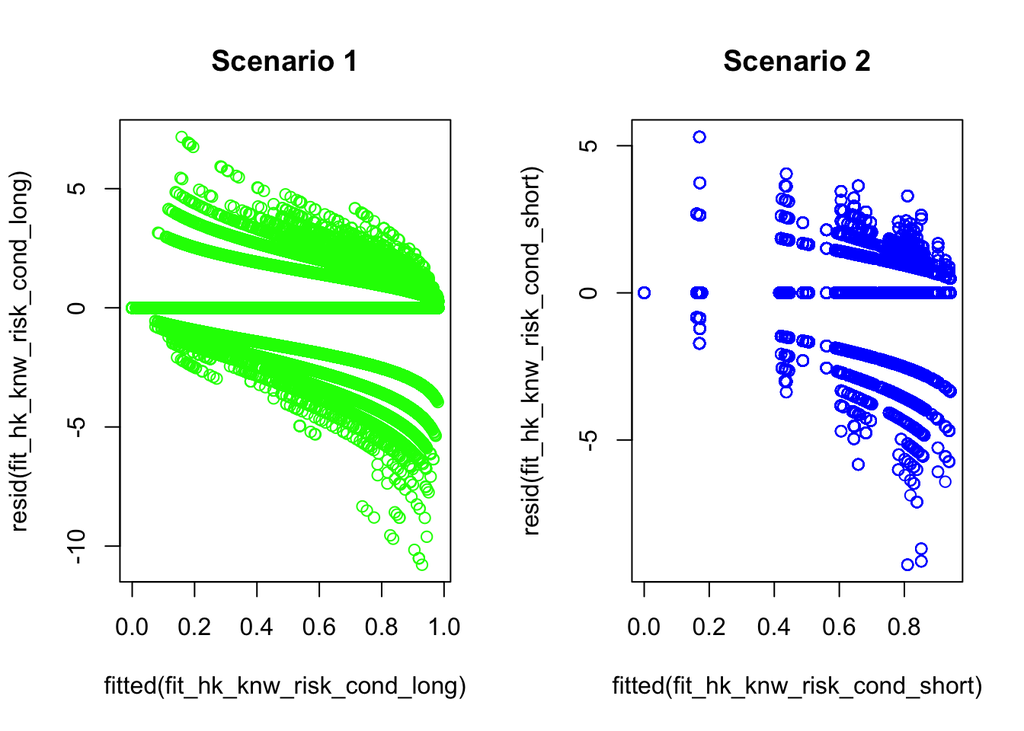

```r
par(mfrow = c(1, 2))
plot(fitted(fit_hk_knw_risk_cond_long), resid(fit_hk_knw_risk_cond_long), col = 'green', main = 'Scenario 1')
plot(fitted(fit_hk_knw_risk_cond_short), resid(fit_hk_knw_risk_cond_short), col = 'blue', main = 'Scenario 2')
```

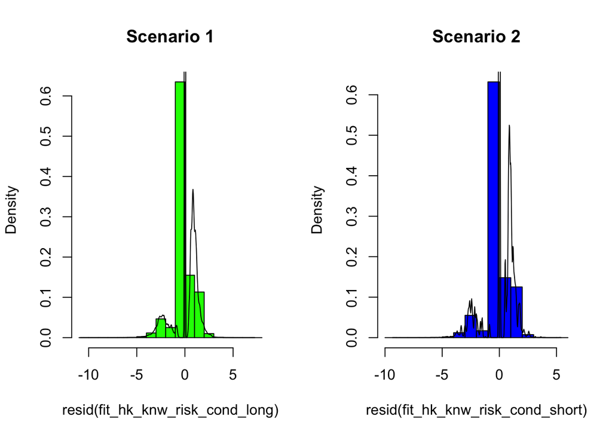

```r
par(mfrow = c(1, 2))
hist(resid(fit_hk_knw_risk_cond_long),
     main = "Scenario 1", prob=TRUE, col = 'green')
lines(density(resid(fit_hk_knw_risk_cond_long)))
hist(resid(fit_hk_knw_risk_cond_short),
     main = "Scenario 2", prob=TRUE, col = 'blue')
lines(density(resid(fit_hk_knw_risk_cond_short)))
```